# Customizing Plots

`scales`, labels, `facet_wrap()`

Author

Casey Schine adapted from Emily Malcolm-White

```r
library(tidyverse)
library(ggthemes)
```

```r
#Import the can_lang dataset
can_lang <- read.csv("https://raw.githubusercontent.com/ttimbers/canlang/master/inst/extdata/can_lang.csv")
```

# A starting graph: scatterplot of `can_lang`

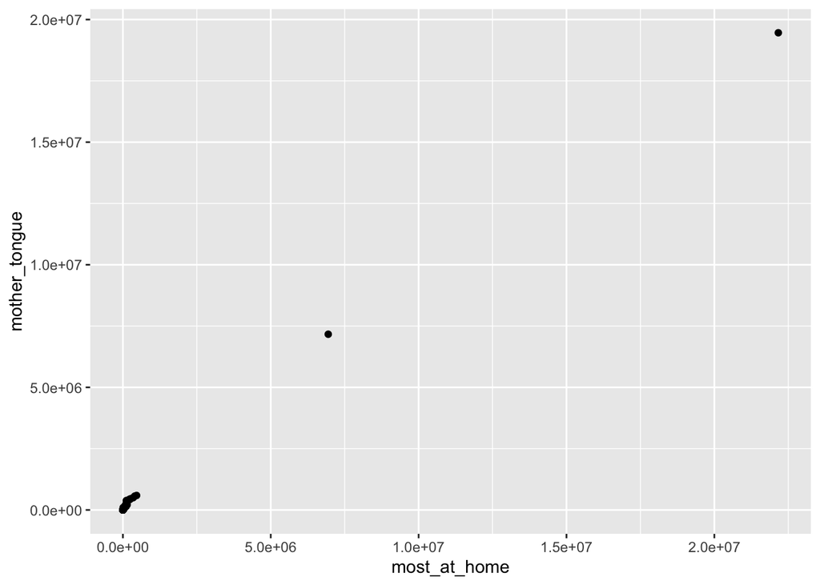

```r
# make base plot (scatter) with x as most_at_home and y as mother_tongue
can_lang|>
ggplot() +
  geom_point(aes(x=most_at_home, y=mother_tongue))
```

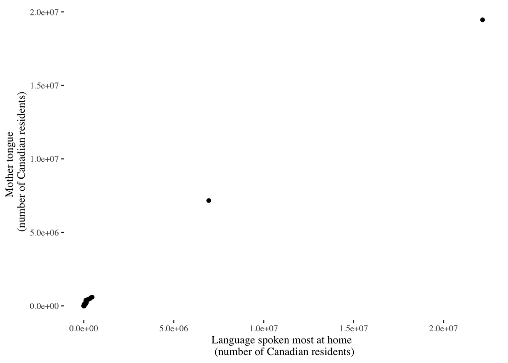

```r
# Assign the plot to and object so it can be recalled

can_lang_baseplot <- can_lang|>
ggplot(aes(x=most_at_home, y=mother_tongue)) +
  geom_point() +
    xlab("Language spoken most at home \n (number of Canadian residents)") +
  ylab("Mother tongue \n (number of Canadian residents)")

can_lang_baseplot +
  theme_tufte()
```

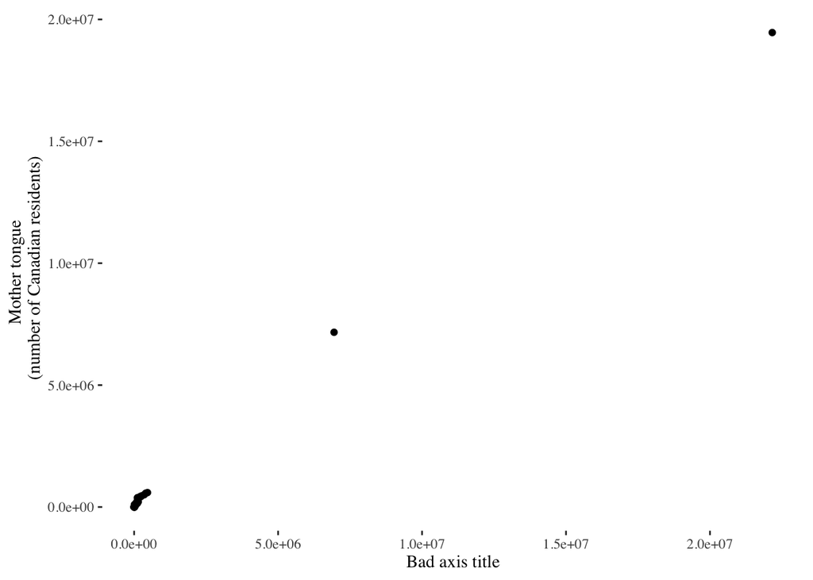

```r
# Use these labels for the axis labels.
  #xlab("Language spoken most at home \n (number of Canadian residents)") +
  #ylab("Mother tongue \n (number of Canadian residents)") +

can_lang_baseplot +
  xlab("Bad axis title") +
  ylab("Mother tongue \n (number of Canadian residents)") +
  theme_tufte()
```

What do you notice about this plot?

**Note**

Note that I assigned this plot to an object and then called the object by name. This makes it possible to build on the plot if you want.

# Axis display format: `scales` package

```r
 # Install the package if needed
library(scales)
```

We want to customize how the continuous x and y axes look, so we need to use the argument `labels=label_comma()` inside a `scale_*_continuous()` layer:

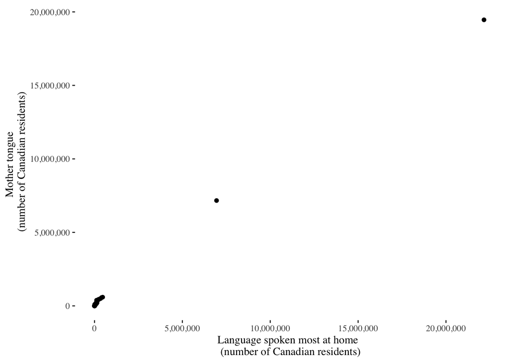

```r
# same base plot, change to scale_*_continuous and use the labels aregument to control the appearance of the axes

can_lang_baseplot +
  scale_x_continuous(labels=label_comma()) +
  scale_y_continuous(labels=label_comma()) +
  theme_tufte()
```

**What other formats are available in the `scales` package?**

When passing a formatting function inside `scale_*_continuous(labels = ...)` you have options!

[output not shown]

Anything else?

## Logarithmic Axes Transformations

**Applying a Log Transformation**

When you apply a log transformation to an axis (or both axes) in a plot, you convert values using a logarithmic scale instead of a linear scale. This means:

- Instead of evenly spaced values (1, 2, 3, 4, …), a logarithmic scale spaces values exponentially (1, 10, 100, 1000, …).
- The distance between ticks represents a multiplicative factor instead of an additive one.

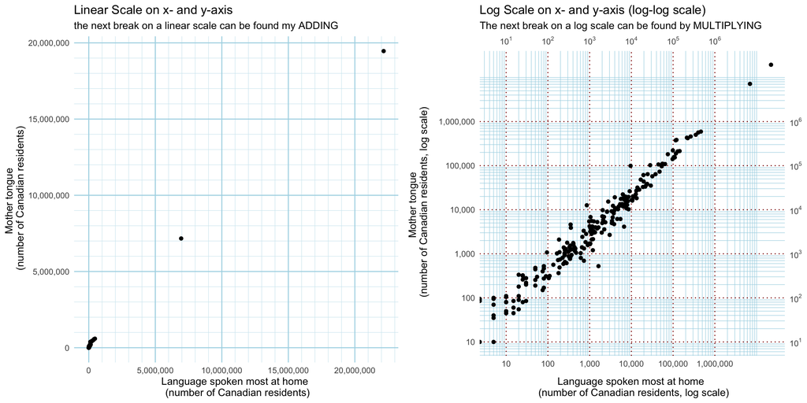

See how much more clearly we can see all the points!

For you to do this yourself, you need to use `scale_*_log10()` instead of `scale_*_continuous()`:

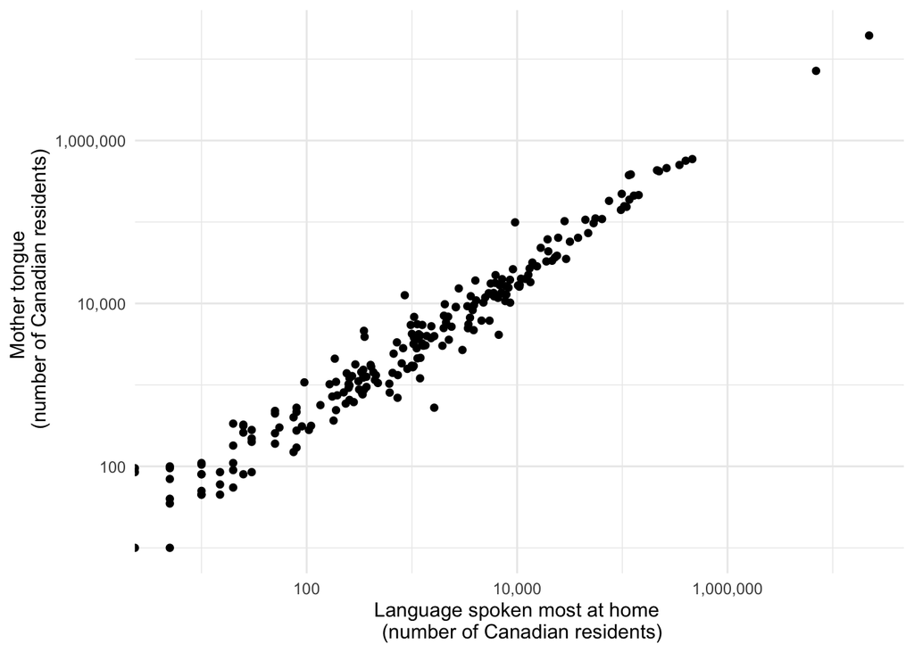

```r
#same plot, change x and y to scale_*_log10
can_lang_baseplot +
  scale_x_log10(labels=label_comma()) +
  scale_y_log10(labels=label_comma()) +
  theme_minimal()
```

1. converts x-axis to a log-scale
2. converts y-axis to a log-scale

**Use ✅ `scale_*_log10()` instead of 🚫`log(variable)`**

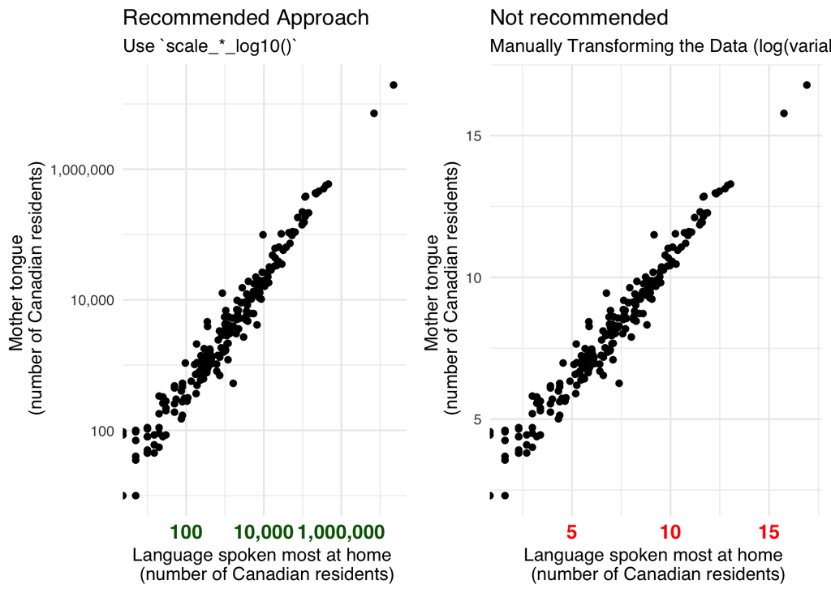

### In-class example of using `scale_*_log10()` instead of `log(variable)`

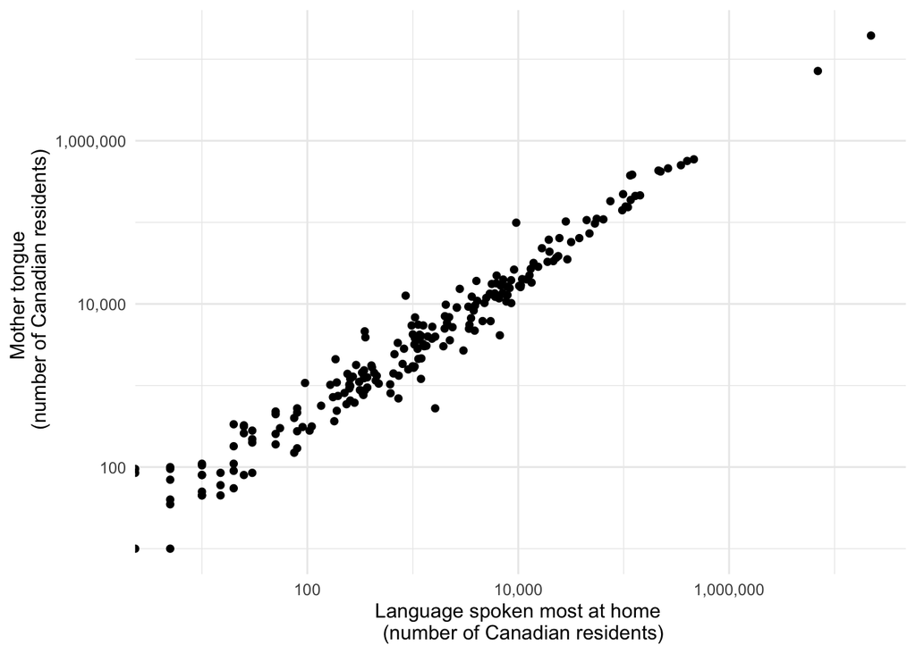

```r
# reuse scale_*_log10() plot from above
can_lang_baseplot +
  scale_x_log10(labels=label_comma()) +
  scale_y_log10(labels=label_comma()) +
  theme_minimal()
```

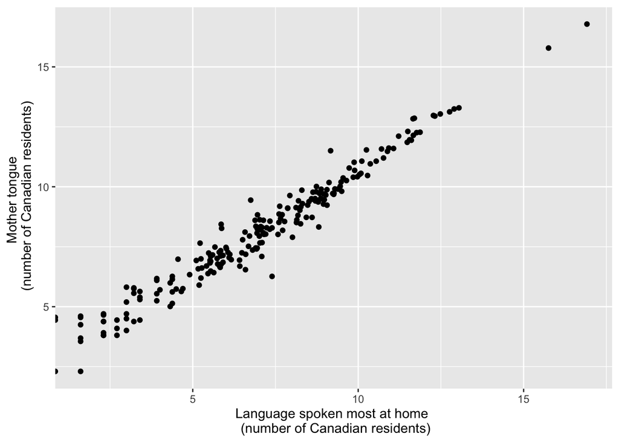

```r
# make the same plot but with log(variable)
can_lang|>
ggplot() +
  geom_point(aes(x=log(most_at_home), y=log(mother_tongue))) +
    xlab("Language spoken most at home \n (number of Canadian residents)") +
  ylab("Mother tongue \n (number of Canadian residents)")
```

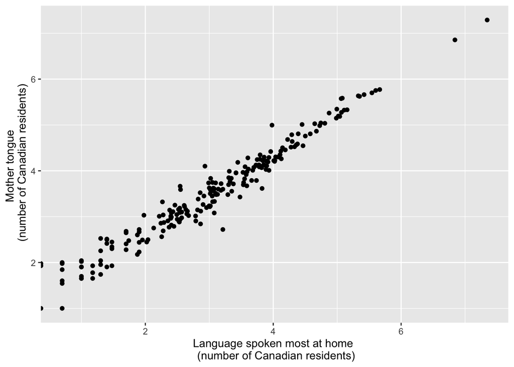

```r
# discuss the difference in the log functions

#remake with the correct log function

can_lang|>
ggplot() +
  geom_point(aes(x=log10(most_at_home), y=log10(mother_tongue))) +
    xlab("Language spoken most at home \n (number of Canadian residents)") +
  ylab("Mother tongue \n (number of Canadian residents)")
```

```r
# discuss the differences between the first and 3rd plots
```

## Using percents on a log scale

### In-class excercise: Make a Scatterplot with Percents and Colors

Create a scatterplot with `most_at_home_percent` and `mother_tongue_percent`. Vary the color and shape of the points depending on the category of language. You may need to adjust the position of the legend:

Use `mutate` to create new columns with percentage of Canadians who speak the language as their mother tongue:

```r
# total population of Canada at time of data collection was 35151728

can_lang_mod <- can_lang |>
  mutate(most_at_home_percent=most_at_home/35151728,
         mother_tongue_percent=mother_tongue/35151728)
```

Create a scatterplot with `most_at_home_percent` and `mother_tongue_percent`. Vary the color and shape of the points depending on the category of language. You may need to adjust the position of the legend:

# Labels

Adding text to a plot is one of the most common forms of annotation. Most plots will not benefit from adding text to every single observation on the plot, but labeling outliers and other important points is very useful.

A add label for each language in this dataset using `geom_text(aes(label = language))`:

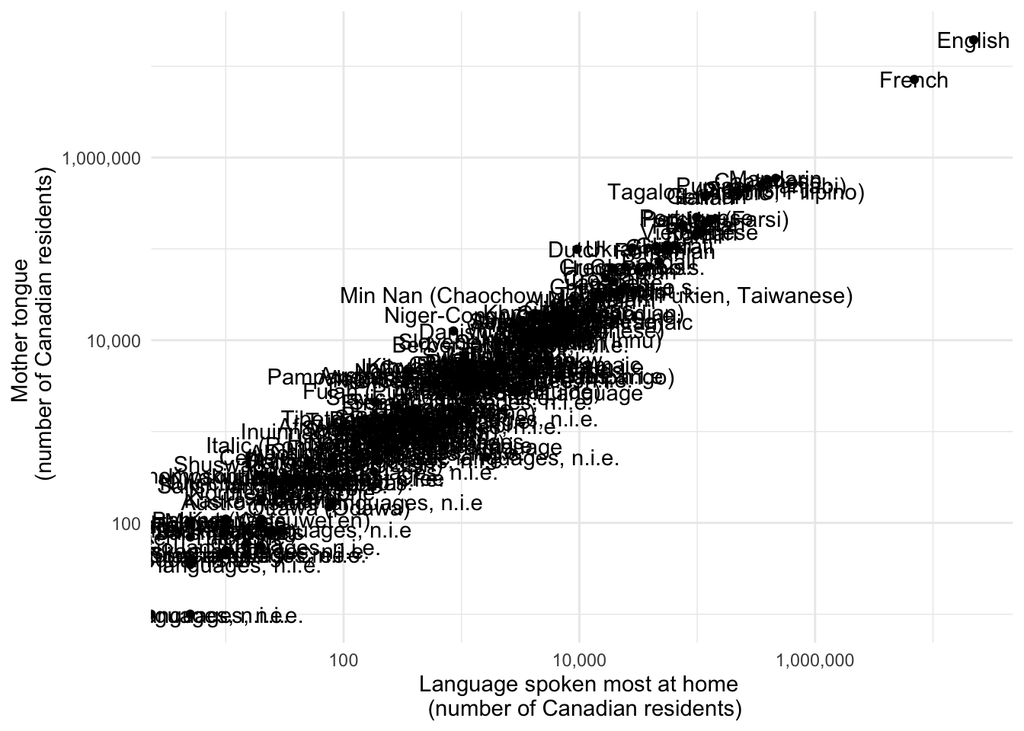

```r
can_lang_baseplot +
  geom_text(aes(label=language)) +
  scale_x_log10(labels=label_comma()) +
  scale_y_log10(labels=label_comma()) +
  theme_minimal()
```

Yikes! This is way too much going on in one plot. A few options to try when this happens:

- Decrease the font size of the labels (using the `size=` argument inside `geom_text`).
- Use the `ggrepel` package to spread out the labels a bit more
- Pick out only a subset of the points to label

## Using `ggrepel`

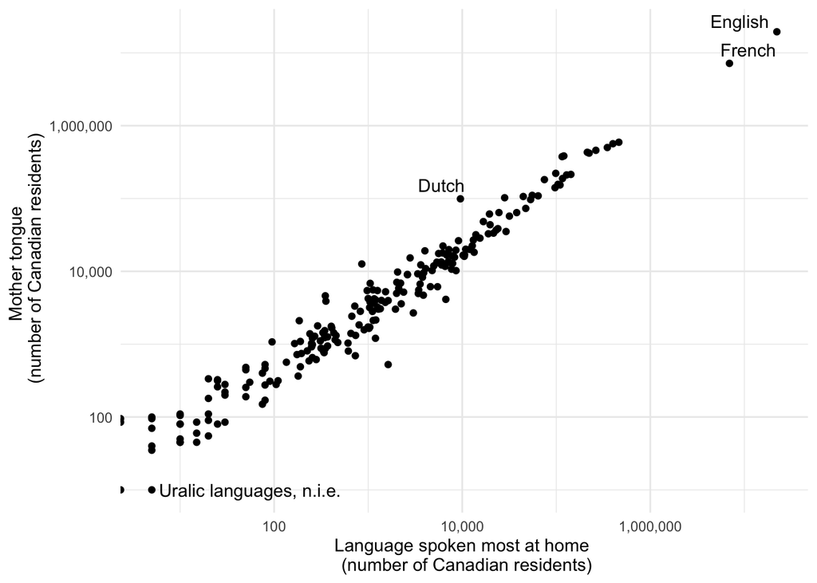

```r
library(ggrepel)

# add labels using geom_text_repel assign label=language in aes()



can_lang_baseplot +
  geom_text_repel(aes(label=language)) +
  scale_x_log10(labels=label_comma()) +
  scale_y_log10(labels=label_comma()) +
  theme_minimal()
```

## Subset the labels

Create a new column for the labels. Use `case_when` (or `ifelse`) to only use the official language names and not to put a label for other language categories.

```r
#mutate new column for official languages using case_when()

can_lang |>
  distinct(category)
```

```
                                 category
1                    Aboriginal languages
2 Non-Official & Non-Aboriginal languages
3                      Official languages
```

```r
can_lang_mod <- can_lang |>
  mutate(official_lang = case_when(category=="Official languages" ~ language,
                                   TRUE ~ NA))


# remember the second half if you are are assigning a value to the things you have not set an explicit rule for you use TRUE ~ NA
```

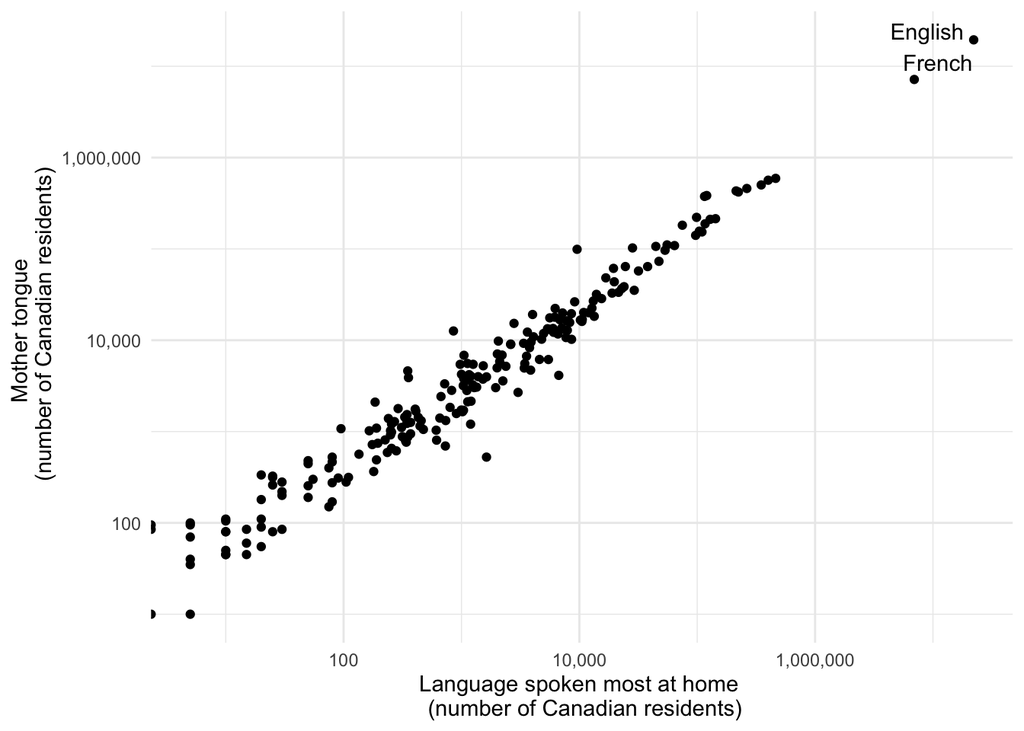

```r
# run code with old base plot

# I had to comment this example out so that the file would render because by design this bit of code is broken
# can_lang_baseplot +
#   geom_text_repel(aes(label=official_lang)) +
#   scale_x_log10(labels=label_comma()) +
#   scale_y_log10(labels=label_comma()) +
#   theme_minimal()


# We need to redo the base plot with the new can_lang dataset with the new official_languages column in it

can_lang_baseplot <- can_lang_mod|>
ggplot(aes(x=most_at_home, y=mother_tongue)) +
  geom_point() +
    xlab("Language spoken most at home \n (number of Canadian residents)") +
  ylab("Mother tongue \n (number of Canadian residents)")


can_lang_baseplot +
  geom_text_repel(aes(label=official_lang)) +
  scale_x_log10(labels=label_comma()) +
  scale_y_log10(labels=label_comma()) +
  theme_minimal()
```

```r
#now make plot, using new base plot with just the official languages labeled
```

# Facet Wrap

`facet_wrap()` is a function in the `ggplot2` package that allows you to create a multi-panel plot showing a similar plot over different subsets of the data, usually different values of a categorical variable.

Create separate side-by-side plots for each different category of language.

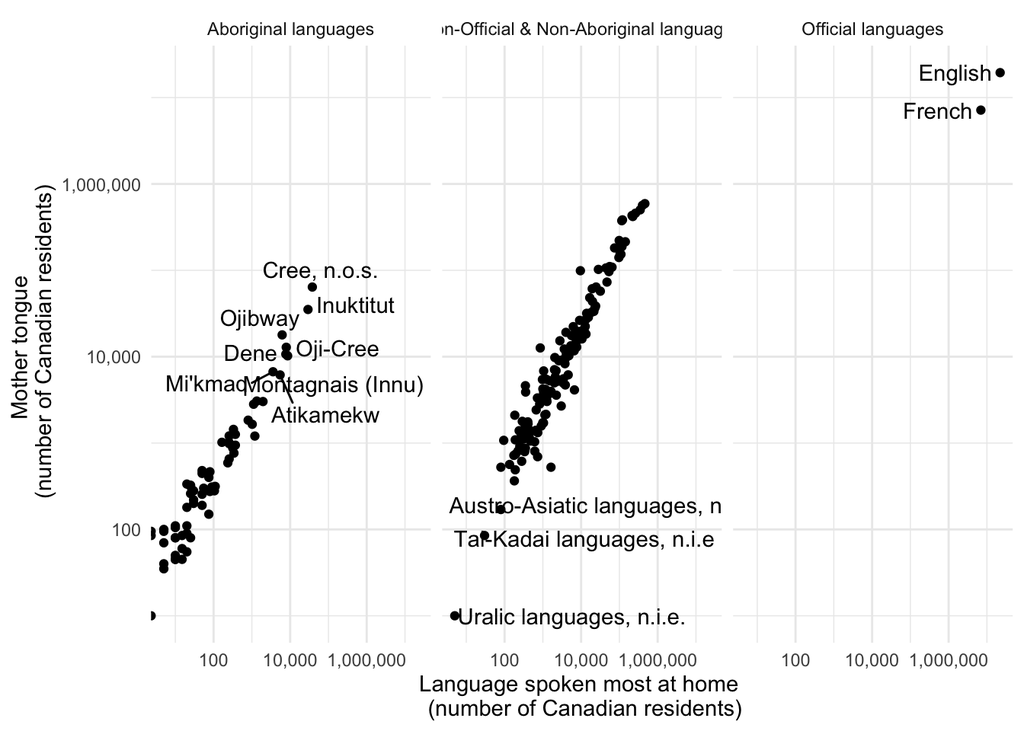

```r
# make the percent plot with facets by category

can_lang_baseplot +
  geom_text_repel(aes(label=language)) +
  scale_x_log10(labels=label_comma()) +
  scale_y_log10(labels=label_comma()) +
  theme_minimal()+
  facet_wrap(~category)
```

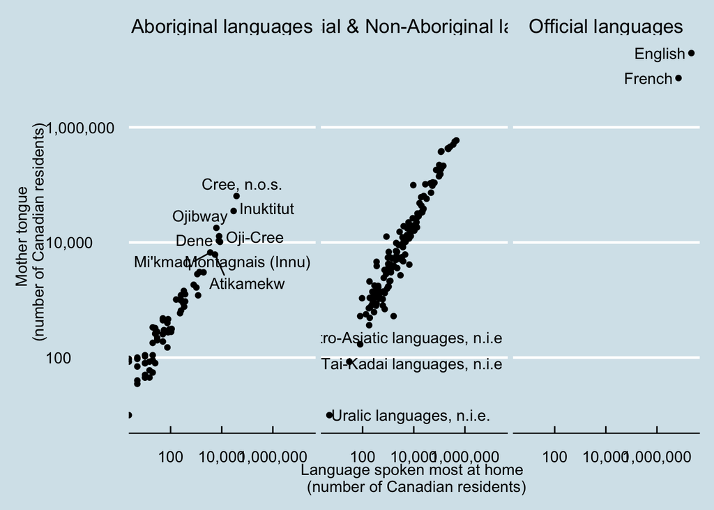

```r
# make the same plot with different themes

can_lang_baseplot +
  geom_text_repel(aes(label=language)) +
  scale_x_log10(labels=label_comma()) +
  scale_y_log10(labels=label_comma()) +
  theme_economist()+
  facet_wrap(~category)
```

```r
# add geom_text_repel to the faceted plot
```